# Lesson 13 - Interview practice

with thanks to Ms. Ashley Chiu

Due 7/28/2020 by 11:59PM PDT

## Background

This lesson is based on a discussion led by a previous Stats 20 TA, Ms. Ashley Chiu. In turn, the discussion was based on a technical interview that one of her friends completed (and got the job)

## Graphics/ Data Visualization

- Effective Story-Telling
- Obvious: People tend to like seeing pictures vs. a table of numbers
- Building blocks/ layering - start with a base plot and add on stylistic elements (“the bells and whistles”)
  - `plot()` + `lines()` + `legend()` + `abline()`
  - `ggplot(, aes())` + many `geom()` + `facet_wrap()` + `scale()` + … many others
- Use domain knowledge appropriately
- Know your audience
- Simple sometimes better

## Base R

- As you’ve seen graphpics in Lesson 8, pretty quick and dirty
- Most plots don’t take too many lines of code (many of the additional features are housed within the initial plotting function)
  - High-level plotting function (e.g. `plot()`) already has arguments for axis labels, titles, colors, etc…
- Much less flexibility, but effective enough depending on the purpose
- Usually works with vectors (there are exceptions to this, as we saw with the scatterplot matrix)

## ggplot2

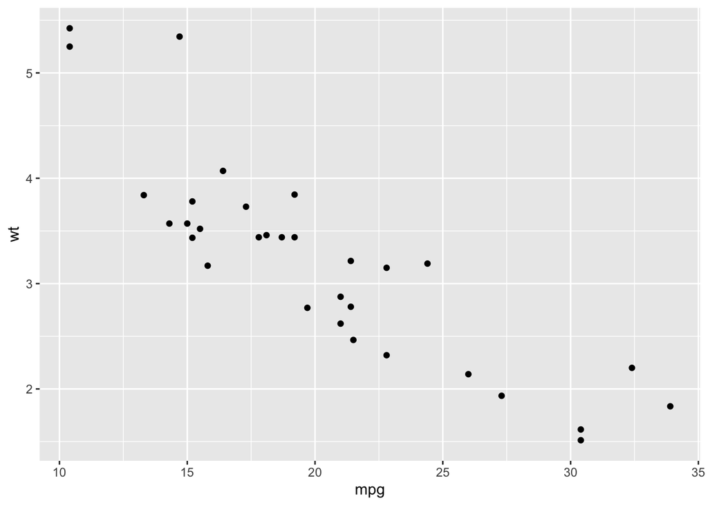

```r
ggplot(mtcars, aes(mpg, wt)) + geom_point()
```

```r
ggsave("example_cars.png")
```

```r
p <- ggplot(mtcars, aes(mpg, wt)) + geom_point()
png("mtcars.png")
print(p)
dev.off()
```

**Data Visualization is not easy!**

It takes practice. For everything else, there’s [Google](https://www.r-bloggers.com/7-visualizations-you-should-learn-in-r/).

## Questions - Are you ready for an interview?

You would d be surprised with how much you can already accomplish after only a few weeks of training…

**Prompt**: You will be analyzing a dataset of housing sales in Ames, Iowa spanning from January 2006 to mid-2010

*Note*: This is actually a [Kaggle](https://www.kaggle.com/c/house-prices-advanced-regression-techniques) data set

**1.** The dataset is called data.csv and the descriptions for each field are supplied in data_description.txt. Each row of data contains one home sale. How many rows and how many columns are in the data set?

**2.** What is the average sale price for homes sold in Ames in 2006? Please rank the neighborhoods with home sales in 2006 from highest average sales price to lowest average sales price. What was the top neighborhood and what was the bottom neighborhood?

**3.** What is the median sale price for homes sold in 2006 which have an indoor square footage of greater than or equal to 2000 ft (excluding porches, garages, decks, and veneers)? What percentage of homes meet this criterion?

*Note on 3*: Challenge yourself! This is a slightly less demanding version of the actual interview question. In reality, you would have been given the additional task of calculating this metric by neighborhood – you should still be able to do this, but we haven’t learned about some of the more elegant ways to do this.

**4.** A client approaches you with a question about the local housing market. They are interested in whether more homes are sold at certain times of year than others? In other words, is there seasonality? Provide a visualization and a brief description of your findings.

*Note*: For the actual visualization, you were allowed to use R plots, Python’s matplotlib, Tableau, Excel charts, or whatever tool you like. Of course, we’ll be required to use R!

**5.** You’re a contractor consulting for a client who wants to remodel their home and then sell it on the market. What factors may be important for them to consider in their remodel? Use a visualization to illustrate your choices.

[figure not shown]

[figure not shown]

# What to Turn in For Credit